# Trabajo grupal - Asignatura 3 - Grupo 4

#### Evaluacion

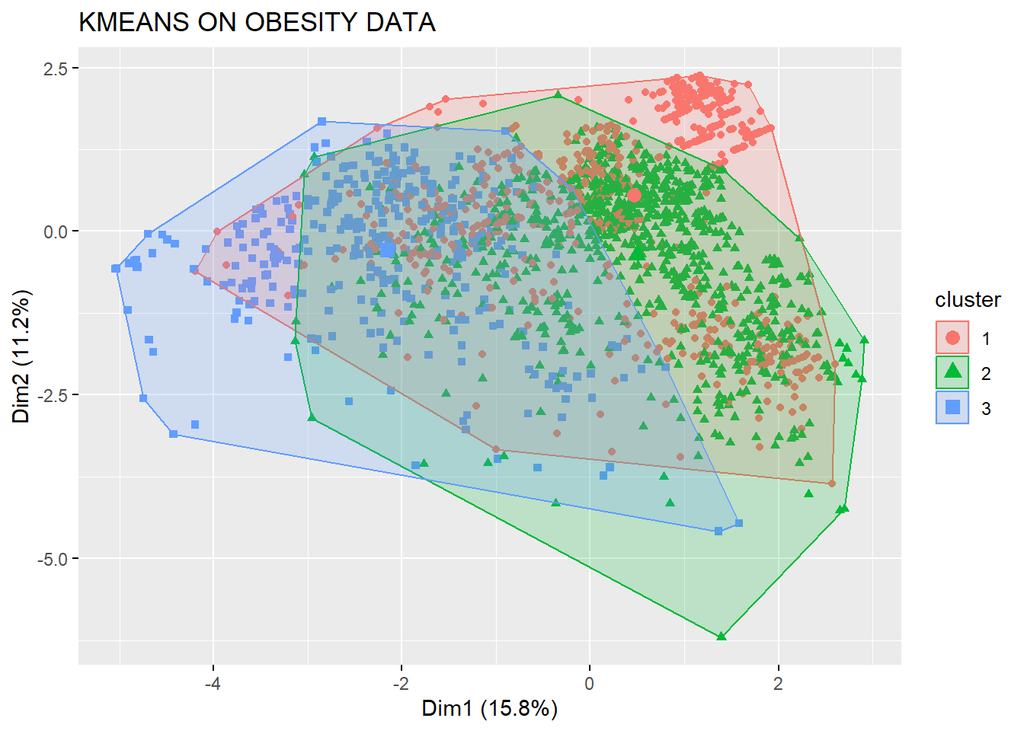

```r
fviz_cluster(obesityClusterKNN, obesity.cluster[,1:15], ellipse = TRUE, geom = "point", main="KMEANS ON OBESITY DATA")
```

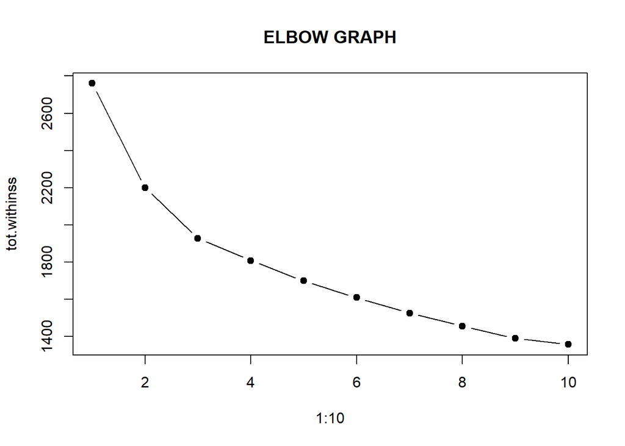

```r
tot.withinss <- vector(mode="character", length=10)
for (i in 1:10){
  obesityClusterKNN <- kmeans(obesity.cluster[,1:15], center=i, nstart=20)
  tot.withinss[i] <- obesityClusterKNN$tot.withinss
}
plot(1:10, tot.withinss, type="b", pch=19, main="ELBOW GRAPH")
```

```
##   cluster size ave.sil.width
## 1       1  286          0.12
## 2       2  245          0.03
## 3       3  730          0.27
## 4       4  850          0.27
```

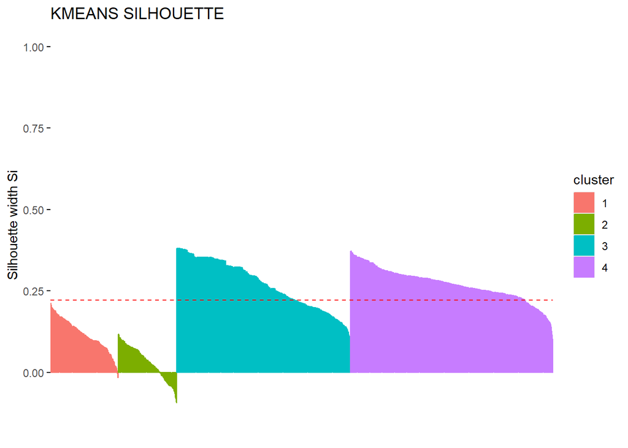

```r
obesityClusterKNN <- kmeans(obesity.cluster[,1:15], center=4, nstart=20)
fviz_silhouette(silhouette(obesityClusterKNN$cluster, dist(obesity.cluster[,1:15])), main="KMEANS SILHOUETTE")
```

Luego de lanzar varios cambios en los hiperparametros kmeans no llega a generar un buen clustering de los datos.

## Cluster Jerarquico

### Minkowski

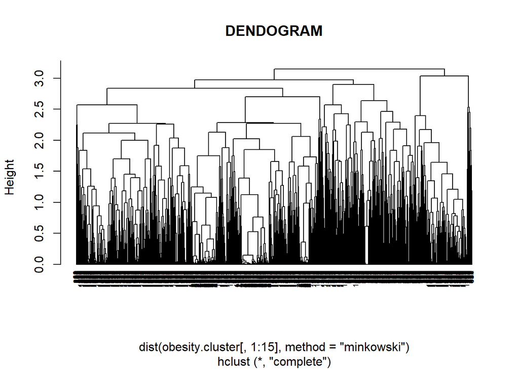

```r
hobesity <- hclust(
  dist(obesity.cluster[,1:15], method="minkowski"),
  method="complete"
  )
plot(hobesity, hang = -1, cex = 0.6, main ="DENDOGRAM")
```

#### Evaluacion

```
##   cluster size ave.sil.width
## 1       1  171          0.05
## 2       2   15          0.15
## 3       3  129          0.19
## 4       4  681          0.26
## 5       5  612          0.08
## 6       6  280          0.12
## 7       7  198          0.14
## 8       8   25          0.02
```

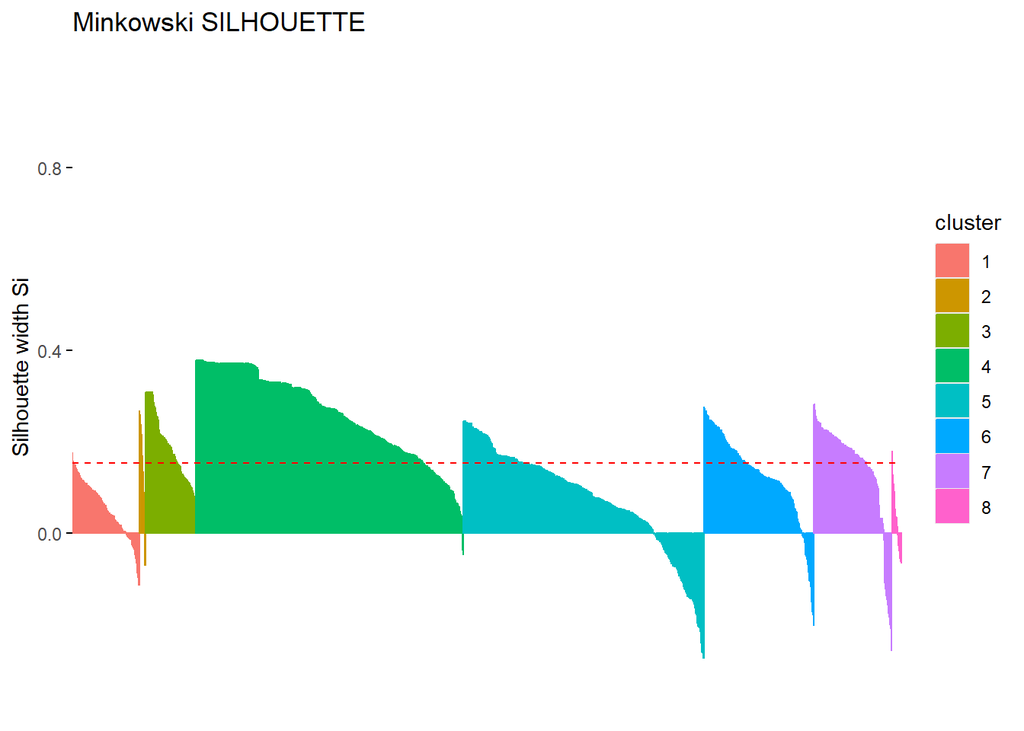

```r
cut_tree <- cutree(hobesity, k = 8)
obesity.cluster$cluster <- cut_tree
fviz_silhouette(silhouette(obesity.cluster$cluster, dist(obesity.cluster[,1:15])), main="Minkowski SILHOUETTE")
```

### Eucledean

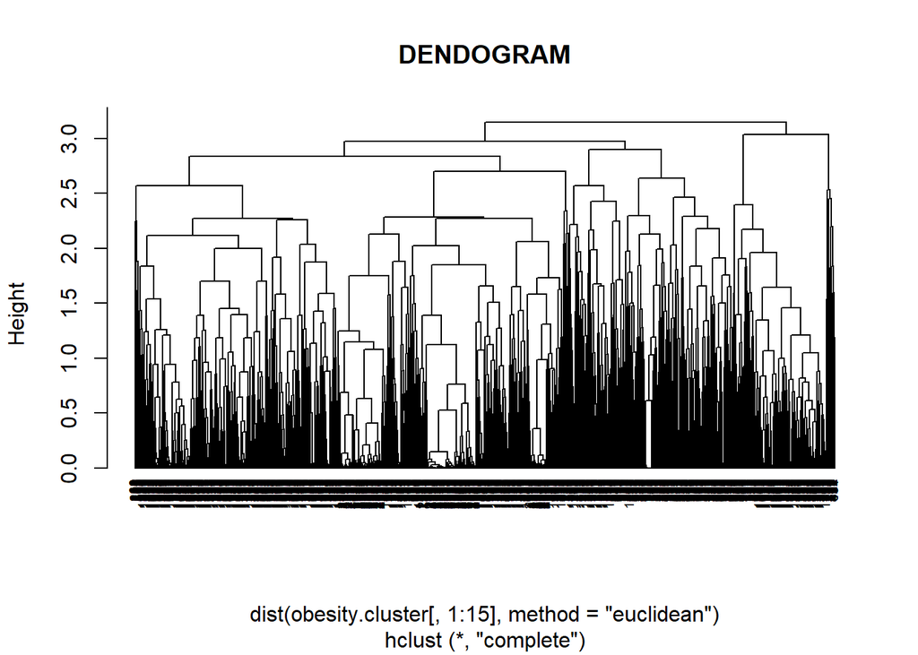

```r
hobesity <- hclust(
  dist(obesity.cluster[,1:15], method="euclidean"),
  method="complete"
  )
plot(hobesity, hang = -1, cex = 0.6, main ="DENDOGRAM")
```

#### Evaluacion

```
##   cluster size ave.sil.width
## 1       1  114          0.14
## 2       2   15          0.13
## 3       3   57          0.20
## 4       4  129          0.18
## 5       5  681          0.26
## 6       6  612          0.07
## 7       7  280          0.12
## 8       8  198          0.14
## 9       9   25          0.02
```

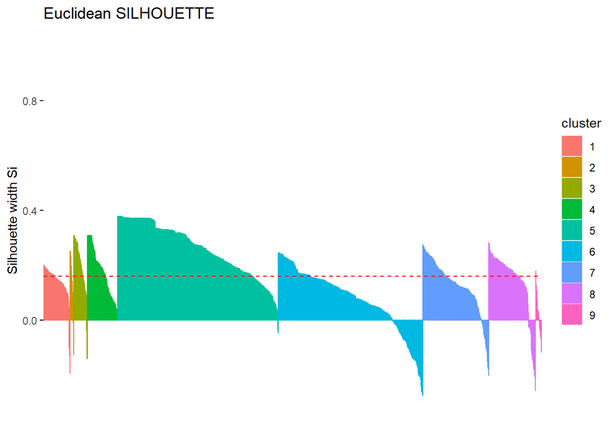

```r
cut_tree <- cutree(hobesity, k = 9)
obesity.cluster$cluster <- cut_tree
fviz_silhouette(silhouette(obesity.cluster$cluster, dist(obesity.cluster[,1:15])), main="Euclidean SILHOUETTE")
```

# Conclusiones

**Fase de exploración**:

- Se realizaron inferencias lógicas válidas a partir de los datos.
- Se evidenció un desbalance significativo en la data, lo que sugiere una posible manipulación posterior a la finalización de la encuesta.
- A pesar de la buena documentación del dataset y la ausencia de datos faltantes, fue necesario aplicar diversas técnicas de transformación.
- La falta de contexto sobre la data dificultó la fase de transformación, especialmente al considerar que los rangos de valores no coincidían con los descritos en la encuesta.

**Modelado predictivo**:

- Se intentó construir modelos predictivos para variables no relacionadas con el estudio principal, lo que evidenció aún más el desbalance de la data.
- Los scores obtenidos no superaron el 0.5, lo que sugiere la necesidad de:
  - Reducir la dimensionalidad de los datos.
  - Realizar más iteraciones de entrenamiento.
  - Ajustar los hiperparámetros de los modelos.
  - Obtener más datos o generar datos sintéticos para equilibrar el conjunto de datos.

**Clasificación**:

- Se logró un excelente score de 0.97 en el punto 3.2 utilizando un modelo de Random Forest.
- Este modelo podría generalizarse mejor con:
  - Más iteraciones de entrenamiento.
  - Reducción de la dimensionalidad de los datos.
  - Optimización de los hiperparámetros.

**Clustering**:

- No se obtuvieron métricas satisfactorias para el clustering.
- Se espera que la mejora en la calidad de los datos y la optimización de los modelos puedan conducir a mejores resultados en el clustering.

**Recomendaciones**:

- Se recomienda obtener más contexto sobre la data para comprender mejor su origen y posibles manipulaciones.
- Es fundamental equilibrar el conjunto de datos antes de construir modelos predictivos.
- Se sugiere aplicar técnicas de reducción de dimensionalidad para mejorar el rendimiento de los modelos.
- Se recomienda realizar más iteraciones de entrenamiento y optimizar los hiperparámetros de los modelos.
- En caso de no ser posible obtener más datos, se podría considerar la generación de datos sintéticos para equilibrar el conjunto de datos.

**Conclusiones generales**:

- El estudio evidenció el impacto del desbalance de datos en el rendimiento de los modelos de aprendizaje automático.
- Se destaca la importancia de contar con datos de calidad y contexto adecuado para obtener resultados confiables.
- El trabajo demuestra el potencial del aprendizaje automático para resolver problemas de clasificación, pero requiere un enfoque cuidadoso para manejar el desbalance de datos y optimizar los modelos.